# Encanto - Isabela’s Ambition - Exploring the caret package

Adapted from a very useful tutorial on the caret package. https://www.machinelearningplus.com/machine-learning/caret-package/ by Selva Prabhakaran

## Loading packages

```r
library(caret) #hyperparameter tuning
library(skimr) #generate descriptive stats
library(RANN)  # required for knnInpute
library(caretEnsemble) #for ensembling predictions
```

## Load dataset

```r
data <- read.csv("Isabela.csv")
head(data)
```

|  | Ambition | Practice_min | Prac_loc_ID | Score_flower | Score_cooking | Flower_deduct | Cooking_deduct | Special_flower | Special_dish | Support_florist | Ave_flower | Ave_cooking | Score_diff | Prac_loc_7 | Pct_flower | Pct_cook | Ave_diff | Prac_loc |
| --- | --- | --- | --- | --- | --- | --- | --- | --- | --- | --- | --- | --- | --- | --- | --- | --- | --- | --- |
| 1 | Florist | 237 | 1 | 1.75 | 1.99 | 0.00 | 0.0 | 0 | 0 | 0.500000 | 1.99 | 1.75 | 0.24 | No | 0.000000 | 0.000000 | 0.24 | 1 |
| 2 | Florist | 239 | 1 | 1.75 | 1.99 | 0.00 | 0.3 | 0 | 1 | 0.600000 | 1.69 | 1.75 | -0.06 | No | 0.150754 | 0.000000 | 0.24 | 1 |
| 3 | Florist | 245 | 1 | 1.86 | 2.09 | 0.17 | 0.0 | 0 | 0 | 0.680000 | 2.09 | 1.69 | 0.40 | No | 0.000000 | 0.091398 | 0.23 | 1 |
| 4 | Housewife | 227 | 1 | 1.69 | 1.69 | 0.00 | 0.0 | 0 | 0 | 0.400000 | 1.69 | 1.69 | 0.00 | No | 0.000000 | 0.000000 | 0.00 | 1 |
| 5 | Florist | 228 | 7 | 1.69 | 1.69 | 0.00 | 0.0 | 0 | 0 | 0.956535 | 1.69 | 1.69 | 0.00 | Yes | 0.000000 | 0.000000 | 0.00 | 0 |
| 6 | Florist | 230 | 7 | 1.69 | 1.99 | 0.00 | 0.0 | 0 | 1 | 0.965228 | 1.99 | 1.69 | 0.30 | Yes | 0.000000 | 0.000000 | 0.30 | 0 |

Explanation (18 variables)  
- `Ambition` Response/outcome variable. Isabela’s ambition to either to become a florist or a housewife  
- `Practice_min` Number of minutes practicing her gift of conjuring flowers or cooking skills  
- `Prac_loc_ID` Practice location  
- `Score_flower` Aesthetics score for flowers created  
- `Score_cooking` Score for dishes cooked  
- `Flower_deduct` Aesthetics score deducted by Abuela  
- `Cooking_deduct` Cooking score deducted by Abuela  
- `Special_flower` Is special flower conjured?  
- `Special_dish` Is special dish cooked?  
- `Support_florist` Is Isabela’s ambition to become a florist supported by other people apart from Abuela?  
- `Ave_flower` Average aesthetics score for flowers created  
- `Ave_cooking` Average score for dishes cooked  
- `Score_diff` Score difference  
- `Prac_loc_7` Is practice location called ‘7’?  
- `Pct_flower` Percentage of aesthetics score deducted  
- `Pct_cook` Percentage of cooking score deducted  
- `Ave_diff` Average score difference  
- `Prac_loc` Practice location

## Split into train and test datasets

```r
# Create the training and test datasets
set.seed(100)

# Get row numbers for the training data
trainRowNumbers <- createDataPartition(data$Ambition, p=0.8, list=FALSE)

# Create the training  dataset
trainData <- data[trainRowNumbers,]

# Create the test dataset
testData <- data[-trainRowNumbers,]

# Store X and Y for later use.
x = trainData[, 2:18]
y = trainData$Ambition
```

## Descriptive statistics

```r
skimmed <- skim(trainData)
skimmed[, c(1:5, 9:11, 13, 15:16)]
```

Data summary

| Name | trainData |
| --- | --- |
| Number of rows | 857 |
| Number of columns | 18 |
| _______________________ |  |
| Column type frequency: |  |
| character | 2 |
| numeric | 16 |
| ________________________ |  |
| Group variables | None |

**Variable type: character**

| skim_variable | n_missing | complete_rate | min | whitespace |
| --- | --- | --- | --- | --- |
| Ambition | 0 | 1 | 7 | 0 |
| Prac_loc_7 | 0 | 1 | 2 | 0 |

**Variable type: numeric**

| skim_variable | n_missing | complete_rate | mean | sd | p25 | p75 | p100 |
| --- | --- | --- | --- | --- | --- | --- | --- |
| Practice_min | 0 | 1.00 | 254.16 | 15.64 | 240.00 | 268.00 | 278.00 |
| Prac_loc_ID | 1 | 1.00 | 4.01 | 2.33 | 2.00 | 7.00 | 7.00 |
| Score_flower | 0 | 1.00 | 1.87 | 0.10 | 1.79 | 1.99 | 2.09 |
| Score_cooking | 2 | 1.00 | 2.08 | 0.14 | 1.99 | 2.18 | 2.29 |
| Flower_deduct | 1 | 1.00 | 0.05 | 0.12 | 0.00 | 0.00 | 0.50 |
| Cooking_deduct | 4 | 1.00 | 0.13 | 0.22 | 0.00 | 0.24 | 0.80 |
| Special_flower | 2 | 1.00 | 0.15 | 0.36 | 0.00 | 0.00 | 1.00 |
| Special_dish | 5 | 0.99 | 0.17 | 0.37 | 0.00 | 0.00 | 1.00 |
| Support_florist | 3 | 1.00 | 0.56 | 0.31 | 0.33 | 0.84 | 1.00 |
| Ave_flower | 5 | 0.99 | 1.96 | 0.26 | 1.69 | 2.13 | 2.29 |
| Ave_cooking | 1 | 1.00 | 1.81 | 0.15 | 1.75 | 1.89 | 2.09 |
| Score_diff | 0 | 1.00 | 0.14 | 0.27 | 0.00 | 0.32 | 0.64 |
| Pct_flower | 4 | 1.00 | 0.06 | 0.10 | 0.00 | 0.12 | 0.40 |
| Pct_cook | 2 | 1.00 | 0.03 | 0.06 | 0.00 | 0.00 | 0.25 |
| Ave_diff | 0 | 1.00 | 0.22 | 0.11 | 0.14 | 0.30 | 0.44 |
| Prac_loc | 2 | 1.00 | 1.59 | 1.43 | 0.00 | 3.00 | 4.00 |

## Impute missing values

Impute missing values using k-Nearest Neighbours using the preProcess function.

```r
# Create the knn imputation model on the training data
preProcess_missingdata_model <- preProcess(trainData, method='knnImpute')
preProcess_missingdata_model
```

```
## Created from 827 samples and 18 variables
##
## Pre-processing:
##   - centered (16)
##   - ignored (2)
##   - 5 nearest neighbor imputation (16)
##   - scaled (16)
```

```r
# Use the imputation model to predict the values of missing data points
trainData <- predict(preProcess_missingdata_model, newdata = trainData)
anyNA(trainData)
```

```
## [1] FALSE
```

All missing values were imputed.

## Create One-Hot Encoding (dummy variables)

Categorical variables need to be converted to numeric variables in order to run.

```r
# Creating dummy variables is converting a categorical variable to as many binary variables as here are categories.
dummies_model <- dummyVars(Ambition ~ ., data=trainData)

# Create the dummy variables using predict. The Y variable (Ambition) will not be present in trainData_mat.
trainData_mat <- predict(dummies_model, newdata = trainData)

# # Convert to dataframe
trainData <- data.frame(trainData_mat)

# # See the structure of the new dataset
str(trainData)
```

```
## 'data.frame':    857 obs. of  18 variables:
##  $ Practice_min   : num  -1.097 -0.969 -0.586 -1.737 -1.673 ...
##  $ Prac_loc_ID    : num  -1.29 -1.29 -1.29 -1.29 1.29 ...
##  $ Score_flower   : num  -1.1422 -1.1422 -0.0592 -1.7329 -1.7329 ...
##  $ Score_cooking  : num  -0.6795 -0.6795 0.0498 -2.8676 -2.8676 ...
##  $ Flower_deduct  : num  -0.444 -0.444 0.981 -0.444 -0.444 ...
##  $ Cooking_deduct : num  -0.578 0.793 -0.578 -0.578 -0.578 ...
##  $ Special_flower : num  -0.425 -0.425 -0.425 -0.425 -0.425 ...
##  $ Special_dish   : num  -0.447 2.235 -0.447 -0.447 -0.447 ...
##  $ Support_florist: num  -0.211 0.116 0.378 -0.539 1.284 ...
##  $ Ave_flower     : num  0.13 -1.037 0.519 -1.037 -1.037 ...
##  $ Ave_cooking    : num  -0.432 -0.432 -0.843 -0.843 -0.843 ...
##  $ Score_diff     : num  0.352 -0.744 0.936 -0.525 -0.525 ...
##  $ Prac_loc_7No   : num  1 1 1 1 0 0 0 0 0 0 ...
##  $ Prac_loc_7Yes  : num  0 0 0 0 1 1 1 1 1 1 ...
##  $ Pct_flower     : num  -0.587 0.861 -0.587 -0.587 -0.587 ...
##  $ Pct_cook       : num  -0.44 -0.44 1 -0.44 -0.44 ...
##  $ Ave_diff       : num  0.21 0.21 0.118 -2.012 -2.012 ...
##  $ Prac_loc       : num  -0.412 -0.412 -0.412 -0.412 -1.111 ...
```

## Transform data

After imputing missing values and performing one-hot-encoding on variables, it’s now time to transform the variables in the train dataset.

```r
preProcess_range_model <- preProcess(trainData, method='range') # range = normalise values so that it ranges from 0 to 1
trainData <- predict(preProcess_range_model, newdata = trainData)

# Append the Y variable
trainData$Ambition <- y

apply(trainData[, 1:10], 2, FUN=function(x){c('min'=min(x), 'max'=max(x))})
```

```
##     Practice_min Prac_loc_ID Score_flower Score_cooking Flower_deduct
## min            0           0            0             0             0
## max            1           1            1             1             1
##     Cooking_deduct Special_flower Special_dish Support_florist Ave_flower
## min              0              0            0               0          0
## max              1              1            1               1          1
```

## Visualise importance of variables

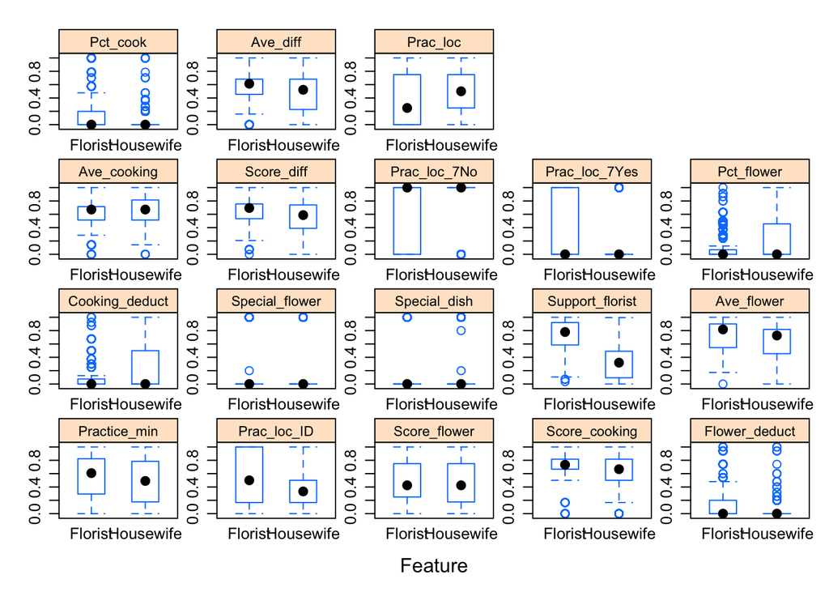

```r
# y variable must be factor

trainData$Ambition <- as.factor(trainData$Ambition)

#pdf("boxplot.pdf", width=10, height=10)

featurePlot(x = trainData[, 1:18],
            y = trainData$Ambition,
            plot = "box",
            strip=strip.custom(par.strip.text=list(cex=.7)),
            scales = list(x = list(relation="free"),
                          y = list(relation="free")))
```

```r
#dev.off()
```

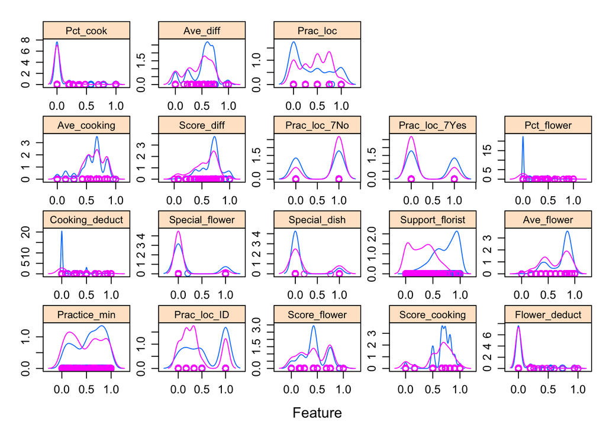

```r
#pdf("density.pdf", width=10, height=10)

featurePlot(x = trainData[, 1:18],
            y = trainData$Ambition,
            plot = "density",
            strip=strip.custom(par.strip.text=list(cex=.7)),
            scales = list(x = list(relation="free"),
                          y = list(relation="free")))
```

```r
#dev.off()
```

Similarly, for the density plots, variables that are important are likely to have density curves that are significantly different for the two outcomes. Again, the `Support_florist` variable shows rather different density curves.

## Feature selection with recursive feature elimination

Recursive feature elimination (RFE) is used for selecting important features that are predictive of the outcome.

```r
set.seed(100)
options(warn=-1)

subsets <- c(1:5, 10, 15, 18)

ctrl <- rfeControl(functions = rfFuncs,
                   method = "repeatedcv",
                   repeats = 5,
                   verbose = FALSE)

lmProfile <- rfe(x=trainData[, 1:18], y=trainData$Ambition,
                 sizes = subsets,
                 rfeControl = ctrl)

lmProfile
```

```
##
## Recursive feature selection
##
## Outer resampling method: Cross-Validated (10 fold, repeated 5 times)
##
## Resampling performance over subset size:
##
##  Variables Accuracy  Kappa AccuracySD KappaSD Selected
##          1   0.7815 0.5340    0.03321 0.07347
##          2   0.8210 0.6219    0.04125 0.08631
##          3   0.8243 0.6296    0.04133 0.08696        *
##          4   0.8112 0.6036    0.04315 0.09059
##          5   0.8119 0.6048    0.04300 0.09022
##         10   0.8131 0.6050    0.04039 0.08581
##         15   0.8133 0.6048    0.03993 0.08518
##         18   0.8115 0.6017    0.04319 0.09164
##
## The top 3 variables (out of 3):
##    Support_florist, Score_diff, Prac_loc_ID
```

## Train the model

See what models the `caret` package supports.

```r
# See available algorithms in caret
modelnames <- paste(names(getModelInfo()), collapse=',  ')
modelnames
```

```
## [1] "ada,  AdaBag,  AdaBoost.M1,  adaboost,  amdai,  ANFIS,  avNNet,  awnb,  awtan,  bag,  bagEarth,  bagEarthGCV,  bagFDA,  bagFDAGCV,  bam,  bartMachine,  bayesglm,  binda,  blackboost,  blasso,  blassoAveraged,  bridge,  brnn,  BstLm,  bstSm,  bstTree,  C5.0,  C5.0Cost,  C5.0Rules,  C5.0Tree, …
```

Let’s train a Multivariate Adaptive Regression Splines model by setting method = "earth.

```r
# Set the seed for reproducibility
set.seed(100)

# Train the model and predict on the training data itself.
model_mars = train(Ambition ~ ., data=trainData, method='earth')
fitted <- predict(model_mars)

model_mars
```

```
## Multivariate Adaptive Regression Spline
##
## 857 samples
##  18 predictor
##   2 classes: 'Florist', 'Housewife'
##
## No pre-processing
## Resampling: Bootstrapped (25 reps)
## Summary of sample sizes: 857, 857, 857, 857, 857, 857, ...
## Resampling results across tuning parameters:
##
##   nprune  Accuracy   Kappa
##    2      0.8116999  0.5969106
##    9      0.8234148  0.6245781
##   17      0.8105738  0.5975440
##
## Tuning parameter 'degree' was held constant at a value of 1
## Accuracy was used to select the optimal model using the largest value.
## The final values used for the model were nprune = 9 and degree = 1.
```

## Compute variable importance

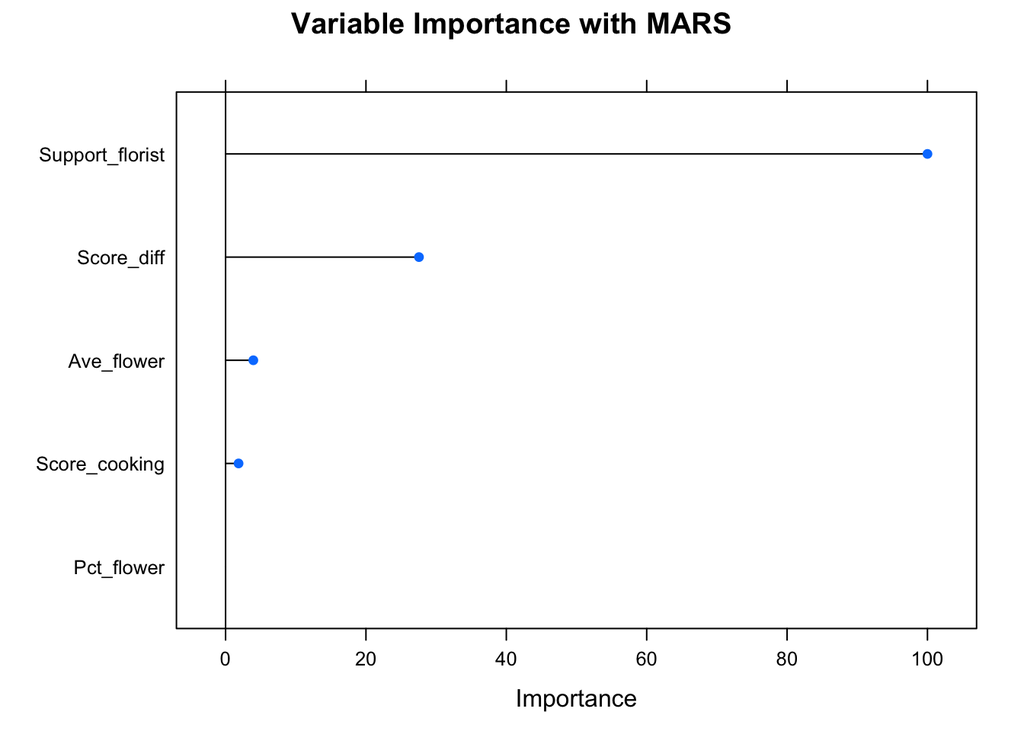

```r
varimp_mars <- varImp(model_mars)
plot(varimp_mars, main="Variable Importance with MARS")
```

As expected, `Support_florist` was the most used variable, followed by `Score_diff`, and `Ave_flower`.

## Generate test dataset and run prediction

In order for the model to predict on the test dataset, we need to preprocess and transform the dataset just as we did on the train dataset.  
All the information required for pre-processing is stored in `preProcess_missingdata_model`, `dummies_model` and `preProcess_range_model`.

```r
# Step 1: Impute missing values
testData2 <- predict(preProcess_missingdata_model, testData)

# Step 2: Create one-hot encodings (dummy variables)
testData3 <- predict(dummies_model, testData2)

# Step 3: Transform the features to range between 0 and 1
testData4 <- predict(preProcess_range_model, testData3)

# View
head(testData4[, 1:10])
```

```
##    Practice_min Prac_loc_ID Score_flower Score_cooking Flower_deduct
## 7    0.09803922   1.0000000        0.000     0.5000000             0
## 11   0.25490196   1.0000000        0.425     0.6666667             0
## 18   0.80392157   0.1666667        0.425     0.8166667             0
## 21   0.58823529   1.0000000        0.425     0.8166667             0
## 33   0.94117647   0.1666667        0.675     0.8166667             0
## 35   0.47058824   0.3333333        0.750     0.9000000             0
##    Cooking_deduct Special_flower Special_dish Support_florist Ave_flower
## 7             0.5              1            1       0.9722332  0.3636364
## 11            0.0              0            0       0.9886583  0.8181818
## 18            0.0              0            1       0.4000146  0.9000000
## 21            0.0              0            0       0.6000274  0.9000000
## 33            1.0              0            1       0.6800325  0.1727273
## 35            0.0              0            0       0.5440238  0.9454545
```

## Run prediction on the test dataset

```r
# Predict on testData
predicted <- predict(model_mars, testData4)
head(predicted)
```

```
## [1] Florist   Florist   Florist   Florist   Housewife Florist
## Levels: Florist Housewife
```

## Confusion matrix

Create a tabular representation to compare predictions to actual values.  
We can set mode = “everything” to compute all the classification evaluation metrics.

```r
# Compute the confusion matrix

testData$Ambition <- as.factor(testData$Ambition)

confusionMatrix(reference = testData$Ambition, data = predicted, mode='everything', positive='Florist')
```

```
## Confusion Matrix and Statistics
##
##            Reference
## Prediction  Florist Housewife
##   Florist       114        26
##   Housewife      16        57
##
##                Accuracy : 0.8028
##                  95% CI : (0.743, 0.854)
##     No Information Rate : 0.6103
##     P-Value [Acc > NIR] : 1.281e-09
##
##                   Kappa : 0.5762
##
##  Mcnemar's Test P-Value : 0.1649
##
##             Sensitivity : 0.8769
##             Specificity : 0.6867
##          Pos Pred Value : 0.8143
##          Neg Pred Value : 0.7808
##               Precision : 0.8143
##                  Recall : 0.8769
##                      F1 : 0.8444
##              Prevalence : 0.6103
##          Detection Rate : 0.5352
##    Detection Prevalence : 0.6573
##       Balanced Accuracy : 0.7818
##
##        'Positive' Class : Florist
##
```

Accuracy : 0.80 or 80%.

## Evaluate performance of multiple algorithms

We can use the resamples function to evaluate multiple machine learning models. Let’s start by training some algorithms.

We can perform hyperparameter tuning using the train function in two ways:

> > Set the tuneLength  
> > Define and set the tuneGrid

`tuneLength` = the number of unique values for tuning parameters. Caret will automatically determine the values each parameter should take.

`tuneGrid` = allows you to control what values should be considered for each parameter.

First, let’s set up the trainControl.

```r
# Define the training control
fitControl <- trainControl(
    method = 'cv',                   # k-fold cross validation
    number = 5,                      # number of folds
    savePredictions = 'final',       # saves predictions for optimal tuning parameter
    classProbs = T,                  # should class probabilities be returned
    summaryFunction=twoClassSummary  # results summary function, use twoClassSummary if the response variable is binary class
)
```

### Training MARS

```r
# Step 1: Define the tuneGrid
marsGrid <-  expand.grid(nprune = c(2, 4, 6, 8, 10),
                        degree = c(1, 2, 3))

# Step 2: Tune hyper parameters by setting tuneGrid
set.seed(100)
model_mars3 = train(Ambition ~ ., data=trainData, method='earth', metric='ROC', tuneGrid = marsGrid, trControl = fitControl)
model_mars3
```

```
## Multivariate Adaptive Regression Spline
##
## 857 samples
##  18 predictor
##   2 classes: 'Florist', 'Housewife'
##
## No pre-processing
## Resampling: Cross-Validated (5 fold)
## Summary of sample sizes: 685, 686, 685, 686, 686
## Resampling results across tuning parameters:
##
##   degree  nprune  ROC        Sens       Spec
##   1        2      0.8837092  0.8757143  0.7094075
##   1        4      0.9011512  0.8718315  0.7633198
##   1        6      0.9022966  0.8795421  0.7424242
##   1        8      0.8986413  0.8757143  0.7483492
##   1       10      0.8938458  0.8719048  0.7453641
##   2        2      0.8212388  0.8663553  0.6260968
##   2        4      0.9028221  0.8776374  0.7693351
##   2        6      0.9001307  0.8565201  0.7782451
##   2        8      0.8942283  0.8546520  0.7812754
##   2       10      0.8941091  0.8546337  0.7753053
##   3        2      0.8628493  0.8567033  0.6798281
##   3        4      0.9034469  0.8776007  0.7753053
##   3        6      0.9032174  0.8641575  0.7571687
##   3        8      0.9000451  0.8584615  0.7571235
##   3       10      0.8987295  0.8584982  0.7691090
##
## ROC was used to select the optimal model using the largest value.
## The final values used for the model were nprune = 4 and degree = 3.
```

### Training Adaboost

```r
set.seed(100)

# Train the model using adaboost
model_adaboost = train(Ambition ~ ., data=trainData, method='adaboost', tuneLength=2, trControl = fitControl) #Hyperparameter tuning using tuneLength
model_adaboost
```

```
## AdaBoost Classification Trees
##
## 857 samples
##  18 predictor
##   2 classes: 'Florist', 'Housewife'
##
## No pre-processing
## Resampling: Cross-Validated (5 fold)
## Summary of sample sizes: 685, 686, 685, 686, 686
## Resampling results across tuning parameters:
##
##   nIter  method         ROC        Sens       Spec
##    50    Adaboost.M1    0.8783495  0.8298535  0.7543193
##    50    Real adaboost  0.6871214  0.8412454  0.7483492
##   100    Adaboost.M1    0.8768766  0.8317399  0.7602895
##   100    Real adaboost  0.6625824  0.8412454  0.7543193
##
## ROC was used to select the optimal model using the largest value.
## The final values used for the model were nIter = 50 and method = Adaboost.M1.
```

### Training Random forest

```r
set.seed(100)

# Train the model using rf
model_rf = train(Ambition ~ ., data=trainData, method='rf', tuneLength=5, trControl = fitControl)
model_rf
```

```
## Random Forest
##
## 857 samples
##  18 predictor
##   2 classes: 'Florist', 'Housewife'
##
## No pre-processing
## Resampling: Cross-Validated (5 fold)
## Summary of sample sizes: 685, 686, 685, 686, 686
## Resampling results across tuning parameters:
##
##   mtry  ROC        Sens       Spec
##    2    0.8711563  0.8660989  0.6615106
##    6    0.8871323  0.8565751  0.7333333
##   10    0.8867648  0.8527656  0.7573496
##   14    0.8862704  0.8565751  0.7602895
##   18    0.8850728  0.8508608  0.7723202
##
## ROC was used to select the optimal model using the largest value.
## The final value used for the model was mtry = 6.
```

### Training SVM

```r
set.seed(100)

# Train the model using SVM
model_svmRadial = train(Ambition ~ ., data=trainData, method='svmRadial', tuneLength=15, trControl = fitControl)
model_svmRadial
```

```
## Support Vector Machines with Radial Basis Function Kernel
##
## 857 samples
##  18 predictor
##   2 classes: 'Florist', 'Housewife'
##
## No pre-processing
## Resampling: Cross-Validated (5 fold)
## Summary of sample sizes: 685, 686, 685, 686, 686
## Resampling results across tuning parameters:
##
##   C        ROC        Sens       Spec
##      0.25  0.8968213  0.8795055  0.7274084
##      0.50  0.8980530  0.8776007  0.7214835
##      1.00  0.8977832  0.8776190  0.7334238
##      2.00  0.8934719  0.8718681  0.7303483
##      4.00  0.8915500  0.8794689  0.7154229
##      8.00  0.8868855  0.8890293  0.6825418
##     16.00  0.8823947  0.8870696  0.6854817
##     32.00  0.8767745  0.8889744  0.6583899
##     64.00  0.8600145  0.8889744  0.6524197
##    128.00  0.8486717  0.8813370  0.6494346
##    256.00  0.8413847  0.8832784  0.6284487
##    512.00  0.8313846  0.8871062  0.6196744
##   1024.00  0.8198163  0.8909524  0.6136137
##   2048.00  0.8143498  0.8986081  0.5598372
##   4096.00  0.8113379  0.9024725  0.5388964
##
## Tuning parameter 'sigma' was held constant at a value of 0.06525857
## ROC was used to select the optimal model using the largest value.
## The final values used for the model were sigma = 0.06525857 and C = 0.5.
```

### Compare the models using resamples

```r
# Compare model performances using resample()
models_compare <- resamples(list(ADABOOST=model_adaboost, RF=model_rf, MARS=model_mars3, SVM=model_svmRadial))

# Summary of the models performances
summary(models_compare)
```

```
##
## Call:
## summary.resamples(object = models_compare)
##
## Models: ADABOOST, RF, MARS, SVM
## Number of resamples: 5
##
## ROC
##               Min.   1st Qu.    Median      Mean   3rd Qu.      Max. NA's
## ADABOOST 0.8525253 0.8772245 0.8828932 0.8783495 0.8852878 0.8938166    0
## RF       0.8691198 0.8697618 0.8932262 0.8871323 0.8997868 0.9037669    0
## MARS     0.8808081 0.8943743 0.9044776 0.9034469 0.9146411 0.9229334    0
## SVM      0.8712843 0.8823192 0.9022033 0.8980530 0.9166188 0.9178394    0
##
## Sens
##               Min.   1st Qu.    Median      Mean   3rd Qu.      Max. NA's
## ADABOOST 0.7714286 0.8076923 0.8380952 0.8298535 0.8653846 0.8666667    0
## RF       0.8076923 0.8380952 0.8666667 0.8565751 0.8761905 0.8942308    0
## MARS     0.8365385 0.8476190 0.8952381 0.8776007 0.9038462 0.9047619    0
## SVM      0.8173077 0.8666667 0.8857143 0.8776007 0.8952381 0.9230769    0
##
## Spec
##               Min.   1st Qu.    Median      Mean   3rd Qu.      Max. NA's
## ADABOOST 0.6969697 0.7014925 0.7462687 0.7543193 0.8059701 0.8208955    0
## RF       0.6666667 0.6716418 0.7462687 0.7333333 0.7761194 0.8059701    0
## MARS     0.7272727 0.7761194 0.7761194 0.7753053 0.7910448 0.8059701    0
## SVM      0.6716418 0.6969697 0.7164179 0.7214835 0.7313433 0.7910448    0
```

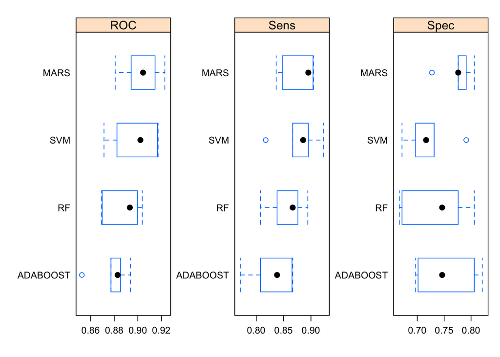

```r
# Draw box plots to compare models

#pdf("compare_models.pdf", width=5, height=5)

scales <- list(x=list(relation="free"), y=list(relation="free"))
bwplot(models_compare, scales=scales)
```

```r
#dev.off()
```

From the boxplots above, we can see that based on the ROC facet, the MARS model appears to be the best performing model overall as it has the highest ROC. Based on the ROC, sensitivity and specificity plots, we can decide which model to pick.

## Ensembling the predictions

We have predictions from multiple individual models and we can use the `caretEnsemble` package. All we need to do is to put the names of the algorithms and pass it to the `caretList` function instead of the `train` function.

```r
# Stacking Algorithms - Run multiple algos in one call.
trainControl <- trainControl(method="repeatedcv",
                             number=10,
                             repeats=3,
                             savePredictions=TRUE,
                             classProbs=TRUE)

algorithmList <- c('rf', 'adaboost', 'earth', 'svmRadial')

set.seed(100)
models <- caretList(Ambition ~ ., data=trainData, trControl=trainControl, methodList=algorithmList)
results <- resamples(models)
summary(results)
```

```
##
## Call:
## summary.resamples(object = results)
##
## Models: rf, adaboost, earth, svmRadial
## Number of resamples: 30
##
## Accuracy
##                Min.   1st Qu.    Median      Mean   3rd Qu.      Max. NA's
## rf        0.7011494 0.7813611 0.8245554 0.8148761 0.8488372 0.8823529    0
## adaboost  0.7241379 0.7794118 0.8023256 0.8074704 0.8372093 0.8720930    0
## earth     0.7529412 0.8117647 0.8304378 0.8311071 0.8501403 0.9069767    0
## svmRadial 0.7647059 0.8000000 0.8245554 0.8268743 0.8567613 0.8953488    0
##
## Kappa
##                Min.   1st Qu.    Median      Mean   3rd Qu.      Max. NA's
## rf        0.3656758 0.5412023 0.6239376 0.6106210 0.6816051 0.7523310    0
## adaboost  0.4266886 0.5487874 0.5851321 0.5958304 0.6567954 0.7248400    0
## earth     0.4883921 0.5879658 0.6400500 0.6410969 0.6839406 0.8073908    0
## svmRadial 0.4991161 0.5598055 0.6190147 0.6298786 0.6897242 0.7774583    0
```

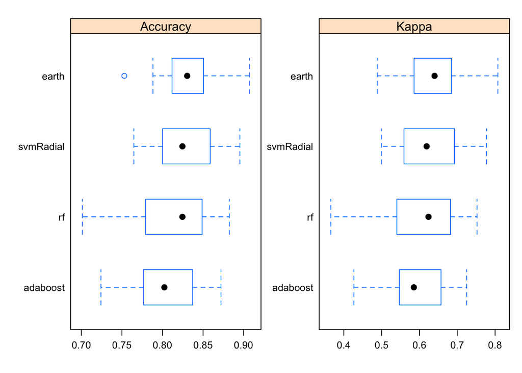

```r
# Box plots to compare models

#pdf("compare_models_caretlist.pdf", width =5, height=3)

scales <- list(x=list(relation="free"), y=list(relation="free"))
bwplot(results, scales=scales)
```

```r
#dev.off()
```

## Combine predictions from multiple models into a final prediction

Let’s combine these predicted values from multiple models and create a new ensemble that predicts better using the `caretStack` function.

```r
# Create the trainControl
set.seed(101)
stackControl <- trainControl(method="repeatedcv",
                             number=10,
                             repeats=3,
                             savePredictions=TRUE,
                             classProbs=TRUE)

# Ensemble the predictions of `models` to form a new combined prediction based on glm
stack.glm <- caretStack(models, method="glm", metric="Accuracy", trControl=stackControl)
print(stack.glm)
```

```
## A glm ensemble of 4 base models: rf, adaboost, earth, svmRadial
##
## Ensemble results:
## Generalized Linear Model
##
## 2571 samples
##    4 predictor
##    2 classes: 'Florist', 'Housewife'
##
## No pre-processing
## Resampling: Cross-Validated (10 fold, repeated 3 times)
## Summary of sample sizes: 2314, 2314, 2313, 2314, 2315, 2313, ...
## Resampling results:
##
##   Accuracy   Kappa
##   0.8329993  0.6446996
```

Ensemble accuracy on the train dataset is 83%.

```r
# Predict on testData
stack_predicteds <- predict(stack.glm, newdata=testData4)
head(stack_predicteds)
```

```
## [1] Florist   Florist   Florist   Florist   Housewife Florist
## Levels: Florist Housewife
```

```r
confusionMatrix(reference = testData$Ambition, data = stack_predicteds, mode='everything', positive='Florist')
```

```
## Confusion Matrix and Statistics
##
##            Reference
## Prediction  Florist Housewife
##   Florist       114        24
##   Housewife      16        59
##
##                Accuracy : 0.8122
##                  95% CI : (0.7532, 0.8623)
##     No Information Rate : 0.6103
##     P-Value [Acc > NIR] : 1.758e-10
##
##                   Kappa : 0.5982
##
##  Mcnemar's Test P-Value : 0.2684
##
##             Sensitivity : 0.8769
##             Specificity : 0.7108
##          Pos Pred Value : 0.8261
##          Neg Pred Value : 0.7867
##               Precision : 0.8261
##                  Recall : 0.8769
##                      F1 : 0.8507
##              Prevalence : 0.6103
##          Detection Rate : 0.5352
##    Detection Prevalence : 0.6479
##       Balanced Accuracy : 0.7939
##
##        'Positive' Class : Florist
##
```